# Unsupervised learning for red and white wine characteristics

First, import the red wine csv file into a pandas dataframe from the following website: https://archive.ics.uci.edu/ml/machine-learning-databases/wine-quality/ Links to an external site. (Note: you need to adjust the argument for read_csv() from sep=',' to sep=';') Use the wine quality data set to answer the following questions. Present any figures that assist you in your analysis:

```python
import pandas as pd
import numpy as np
wine = pd.read_csv("https://archive.ics.uci.edu/ml/machine-learning-databases/wine-quality/winequality-red.csv", sep=';')
```

```python
import matplotlib.pyplot as plt
```

```python
wine.head()
```

|  | fixed acidity | volatile acidity | citric acid | residual sugar | chlorides | free sulfur dioxide | total sulfur dioxide | density | pH | sulphates | alcohol | quality |
| --- | --- | --- | --- | --- | --- | --- | --- | --- | --- | --- | --- | --- |
| 0 | 7.4 | 0.70 | 0.00 | 1.9 | 0.076 | 11.0 | 34.0 | 0.9978 | 3.51 | 0.56 | 9.4 | 5 |
| 1 | 7.8 | 0.88 | 0.00 | 2.6 | 0.098 | 25.0 | 67.0 | 0.9968 | 3.20 | 0.68 | 9.8 | 5 |
| 2 | 7.8 | 0.76 | 0.04 | 2.3 | 0.092 | 15.0 | 54.0 | 0.9970 | 3.26 | 0.65 | 9.8 | 5 |
| 3 | 11.2 | 0.28 | 0.56 | 1.9 | 0.075 | 17.0 | 60.0 | 0.9980 | 3.16 | 0.58 | 9.8 | 6 |
| 4 | 7.4 | 0.70 | 0.00 | 1.9 | 0.076 | 11.0 | 34.0 | 0.9978 | 3.51 | 0.56 | 9.4 | 5 |

### 1. Use K Means Cluster Analysis to identify cluster(s) of observations that have high and low values of the wine quality. (Assume all variables are continuous.) Describe variables that cluster with higher values of wine quality. Describe variables that cluster with lower values of wine quality. If you want to make a good bottle of wine, then what characteristics are most important according to this analysis?

I first scaled the variables before performing k-means clustering. I wrote a program that resembles Grid-Search to test which predictors and number of clusters result in the highest silhouette score. The following were the top 4 scores and clusters:

Score: [Number of clusters, Combination of clusters]

0.9003461030803371: [2, ('chlorides', 'density')]

0.8410584139131765: [2, ('residual sugar', 'density')]

0.8398376912315784: [2, ('residual sugar', 'chlorides')]

0.8398332217360939: [2, ('residual sugar', 'chlorides', 'density')]

I plotted the first three combinations of predictors. I found that chlorides (correlation: -0.13) and density (correlation: -0.175) had a negative relationship with wine quality, while residual sugar (0.014) has a positive relationship with wine quality. These also roughly correlate with the clusters found from k-Means analysis.

When volatile acidity is very high, the wine is of low quality, but a high alcohol content and a low volatile acidity produces the best wine. When volatile acidity is high and the alcohol content is low, the wine is of mediocre quality.

```python
from sklearn.cluster import KMeans
X = wine.iloc[:,:11]
y = wine.iloc[:, -1]
```

```python
X.columns
```

```
Index(['fixed acidity', 'volatile acidity', 'citric acid', 'residual sugar',
       'chlorides', 'free sulfur dioxide', 'total sulfur dioxide', 'density',
       'pH', 'sulphates', 'alcohol'],
      dtype='object')
```

```python
# Scale the variables
from sklearn import preprocessing
scaler = preprocessing.StandardScaler().fit(X)
columns = list(X.columns)
X = pd.DataFrame(preprocessing.scale(X), columns=columns)
```

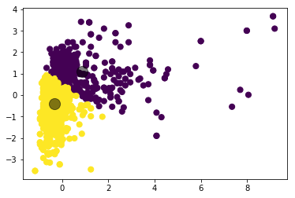

```python
# Residual Sugar vs Density
kmeans = KMeans(n_clusters=2)
X1 = X[['residual sugar', 'density']]
kmeans.fit(X1)
y_kmeans = kmeans.predict(X1)
plt.scatter(X1['residual sugar'], X1['density'], c=y_kmeans, s=50)
centers = kmeans.cluster_centers_ # extract final centroids from each cluster
plt.scatter(centers[:, 0], centers[:, 1], c='black', s=200, alpha=0.5)
```

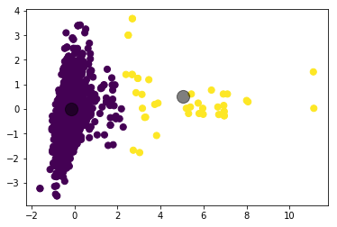

```python
# Chlorides vs Density
kmeans = KMeans(n_clusters=2)
X1 = X[['chlorides', 'density']]
kmeans.fit(X1)
y_kmeans = kmeans.predict(X1)
plt.scatter(X1['chlorides'], X1['density'], c=y_kmeans, s=50)
centers = kmeans.cluster_centers_ # extract final centroids from each cluster
plt.scatter(centers[:, 0], centers[:, 1], c='black', s=200, alpha=0.5)
```

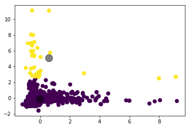

```python
# RESIDUAL SUGAR vs CHLORIDES
kmeans = KMeans(n_clusters=2)
X1 = X[['residual sugar', 'chlorides']]
kmeans.fit(X1)
y_kmeans = kmeans.predict(X1)
plt.scatter(X1['residual sugar'], X1['chlorides'], c=y_kmeans, s=50)
centers = kmeans.cluster_centers_ # extract final centroids from each cluster
plt.scatter(centers[:, 0], centers[:, 1], c='black', s=200, alpha=0.5)
```

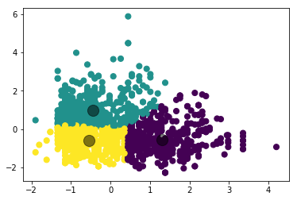

```python
# ALCOHOL vs VOLATILE ACIDITY
kmeans = KMeans(n_clusters=3)
X1 = X[['alcohol', 'volatile acidity']]
kmeans.fit(X1)
y_kmeans = kmeans.predict(X1)
plt.scatter(X1['alcohol'], X1['volatile acidity'], c=y_kmeans, s=50)
centers = kmeans.cluster_centers_ # extract final centroids from each cluster
plt.scatter(centers[:, 0], centers[:, 1], c='black', s=200, alpha=0.5)
```

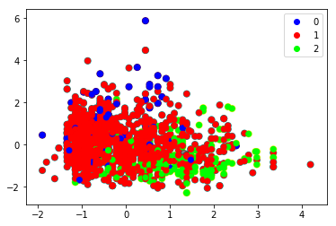

```python
#y ranges from 3 to 8 so split into 3 categories
y_cat = []
for num in y:
    if num in [3,4]:
        y_cat.append(0)
    if num in [5,6]:
        y_cat.append(1)
    if num in [7,8]:
        y_cat.append(2)


labels = y_cat
clset = set(zip(y_cat, labels))

ax = plt.gca()
sc = ax.scatter(X['alcohol'], X['volatile acidity'], c=y_cat, cmap="brg")
handles = [plt.plot([],color=sc.get_cmap()(sc.norm(c)),ls="", marker="o")[0] for c,l in clset ]
labels = [l for c,l in clset]
ax.legend(handles, labels)

plt.show()
```

[output not shown]

total_columns = len(X.columns)

# dictionary to store silhouette scores, number of clusters and variables used, keyed by silohouette score

silhouette_scores = {}

# list of scores to calculate max(score) and key dictionary for values

scores = []

comb_count = 0

count = 2

[output not shown]

## 2. Use Hierarchical Cluster Analysis to identify cluster(s) of observations that have high and low values of the wine quality. (Assume all variables are continuous.) Use complete linkage and the same number of groups that you found to be the most meaningful in question 1. Describe variables that cluster with higher values of wine quality. Describe variables that cluster with lower values of wine quality.

## If you want to make a good bottle of wine, then what characteristics are most important according to this analysis? Have your conclusions changed using Hierarchical clustering rather than k means clustering? Present any figures that assist you in your analysis.

```python
from sklearn.cluster import AgglomerativeClustering
```

```python
# DENDROGRAM
from scipy.cluster.hierarchy import linkage
row_clusters = linkage(X.values, method='complete', metric='euclidean')
```

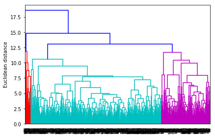

```python
from scipy.cluster.hierarchy import dendrogram
from scipy.spatial.distance import pdist, squareform

# make dendrogram black (part 1/2)
# from scipy.cluster.hierarchy import set_link_color_palette
# set_link_color_palette(['black'])
row_dist = pd.DataFrame(squareform(pdist(X, metric='euclidean')),)
row_dendr = dendrogram(row_clusters
                       # make dendrogram black (part 2/2)
                       # color_threshold=np.inf
                       )
plt.tight_layout()
plt.ylabel('Euclidean distance')
#plt.savefig('./figures/dendrogram.png', dpi=300,
#            bbox_inches='tight')
plt.show()
```

```python
ac = AgglomerativeClustering(n_clusters=3,   # note that we select the clusters
                             affinity='euclidean',
                             linkage='complete')
y_ac = ac.fit_predict(X)    # extract cluster labels for each observation in data
print(y_ac)
```

```
[0 0 0 ... 0 0 0]
```

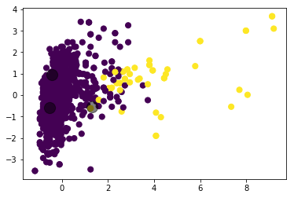

```python
# CHLORIDES vs ALCOHOL

plt.scatter(X['residual sugar'], X['density'], c=y_ac, s=50)
centers = kmeans.cluster_centers_ # extract final centroids from each cluster
plt.scatter(centers[:, 0], centers[:, 1], c='black', s=200, alpha=0.5)
```

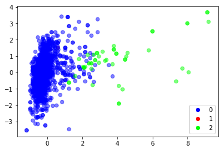

```python
labels = y_ac
clset = set(zip(y_ac, labels))

ax = plt.gca()
sc = ax.scatter(X['residual sugar'], X['density'], c=y_ac, alpha = 0.5, cmap="brg")
handles = [plt.plot([],color=sc.get_cmap()(sc.norm(c)),ls="", marker="o")[0] for c,l in clset ]
labels = [l for c,l in clset]
ax.legend(handles, labels)

plt.show()
```

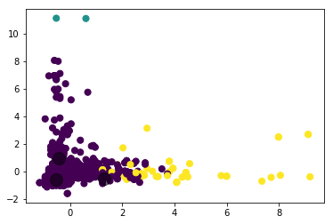

```python
# CHLORIDES vs ALCOHOL

plt.scatter(X['residual sugar'], X['chlorides'], c=y_ac, s=50)
centers = kmeans.cluster_centers_ # extract final centroids from each cluster
plt.scatter(centers[:, 0], centers[:, 1], c='black', s=200, alpha=0.5)
```

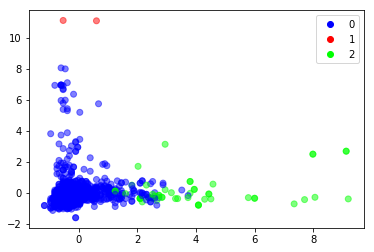

```python
labels = y_ac
clset = set(zip(y_ac, labels))

ax = plt.gca()
sc = ax.scatter(X['residual sugar'], X['chlorides'], c=y_ac, alpha = 0.5, cmap="brg")
handles = [plt.plot([],color=sc.get_cmap()(sc.norm(c)),ls="", marker="o")[0] for c,l in clset ]
labels = [l for c,l in clset]
ax.legend(handles, labels)

plt.show()
```

### 3. Use Principal Components Analysis to reduce the dimensions of your data. How much of the variation in your data is explained by the first two principal components. How might you use the first two components to do supervised learning on some other variable tied to wine (e.g. - wine price)?

The first two principal components explain about 45.7% of the total variance as indicated by the cumulative explained variance. The PCA components can be used for supervised learning on any other variable like price or quality, since they constitute a large proportion of the variance in the predictor variables and are uncorrelated with each other. Since the components are uncorrelated with each other they are suitable for models that require uncorrelated predictors like linear regression and other models that gain predictive power when using independent predictors like decision trees and SVMs. The components can be used as predictors in these models for better accuracy, though this may lead to reduced understanding of how the model works.

```python
from sklearn.decomposition import PCA
pca = PCA(n_components=11)
pca.fit(X)
```

```
PCA(copy=True, iterated_power='auto', n_components=11, random_state=None,
  svd_solver='auto', tol=0.0, whiten=False)
```

```python
print(pca.components_)
```

```
[[ 0.48931422 -0.23858436  0.46363166  0.14610715  0.21224658 -0.03615752
   0.02357485  0.39535301 -0.43851962  0.24292133 -0.11323206]
 [-0.11050274  0.27493048 -0.15179136  0.27208024  0.14805156  0.51356681
   0.56948696  0.23357549  0.00671079 -0.03755392 -0.38618096]
 [-0.12330157 -0.44996253  0.23824707  0.10128338 -0.09261383  0.42879287
   0.3224145  -0.33887135  0.05769735  0.27978615  0.47167322]
 [-0.22961737  0.07895978 -0.07941826 -0.37279256  0.66619476 -0.04353782
  -0.03457712 -0.17449976 -0.00378775  0.55087236 -0.12218109]
 [-0.08261366  0.21873452 -0.05857268  0.73214429  0.2465009  -0.15915198
  -0.22246456  0.15707671  0.26752977  0.22596222  0.35068141]
 [ 0.10147858  0.41144893  0.06959338  0.04915555  0.30433857 -0.01400021
   0.13630755 -0.3911523  -0.52211645 -0.38126343  0.36164504]
 [-0.35022736 -0.5337351   0.10549701  0.29066341  0.37041337 -0.11659611
  -0.09366237 -0.17048116 -0.02513762 -0.44746911 -0.3276509 ]
 [-0.17759545 -0.07877531 -0.37751558  0.29984469 -0.35700936 -0.2047805
   0.01903597 -0.23922267 -0.56139075  0.37460432 -0.21762556]
 [-0.19402091  0.1291103   0.38144967 -0.00752295 -0.11133867 -0.63540522
   0.59211589 -0.02071868  0.16774589  0.05836706 -0.03760311]
 [-0.24952314  0.36592473  0.62167708  0.09287208 -0.21767112  0.24848326
  -0.37075027 -0.23999012 -0.0109696   0.11232046 -0.3030145 ]
 [ 0.63969145  0.0023886  -0.0709103   0.18402996  0.05306532 -0.05142086
   0.0687016  -0.5673319   0.3407109   0.06955538 -0.31452591]]
```

```python
print(pca.explained_variance_)
```

```
[3.10107182 1.92711489 1.55151379 1.21399175 0.95989238 0.66002104
 0.58415655 0.42322138 0.34485779 0.18144664 0.05959558]
```

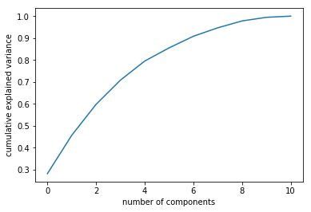

```python
plt.plot(np.cumsum(pca.explained_variance_ratio_))
plt.xlabel('number of components')
plt.ylabel('cumulative explained variance');
```

```python
np.cumsum(pca.explained_variance_ratio_)
```

```
array([0.28173931, 0.45682201, 0.59778051, 0.70807438, 0.79528275,
       0.85524714, 0.90831906, 0.94676967, 0.97810077, 0.99458561,
       1.        ])
```